# EstudoDeCaso1

```r
    top_station_member <- cyclistic_viagens_member %>% count(start_station_name) %>% arrange(desc(n)) %>% head(10)
    worst_station_member <- cyclistic_viagens_member %>% count(start_station_name) %>% arrange(n) %>% head(10)
    bike_pref_member <- cyclistic_viagens_member %>% count(rideable_type) %>% arrange(n)
    weekdays_member <- cyclistic_viagens_member %>% count(weekday) %>% arrange(n)
    period_member <- cyclistic_viagens_member %>% count(periodo) %>% arrange(n)

    #Adicionando uma coluna de hora e uma de período ao dataframe de casuais
    cyclistic_viagens_casual$hora_i <- format(as.POSIXct(cyclistic_viagens_casual$started_at), format= "%H:%M:%S")
    cyclistic_viagens_casual <- cyclistic_viagens_casual %>%
                                  mutate(periodo = case_when(
                                    hora_i >= "06:00:00" & hora_i < "11:59:59" ~"manha",
                                    hora_i >= "12:00:00" & hora_i < "17:59:59" ~"tarde",
                                    hora_i >= "18:00:00" & hora_i < "23:59:59" ~"noite",
                                    TRUE ~"madrugada")
                                  )

    #Estatisticas basicas sobre casuais
    mean(cyclistic_viagens_casual$duration)
```

```
## Time difference of 24.3588 mins
```

```r
    median(cyclistic_viagens_casual$duration)
```

```
## Time difference of 14.08333 mins
```

```r
    max(cyclistic_viagens_casual$duration)
```

```
## Time difference of 34354.07 mins
```

```r
    table(cyclistic_viagens_casual$weekday)
```

```
##
##       domingo  quarta-feira  quinta-feira        sábado segunda-feira
##        296594        200536        226569        361616        207546
##   sexta-feira   terça-feira
##        244987        193418
```

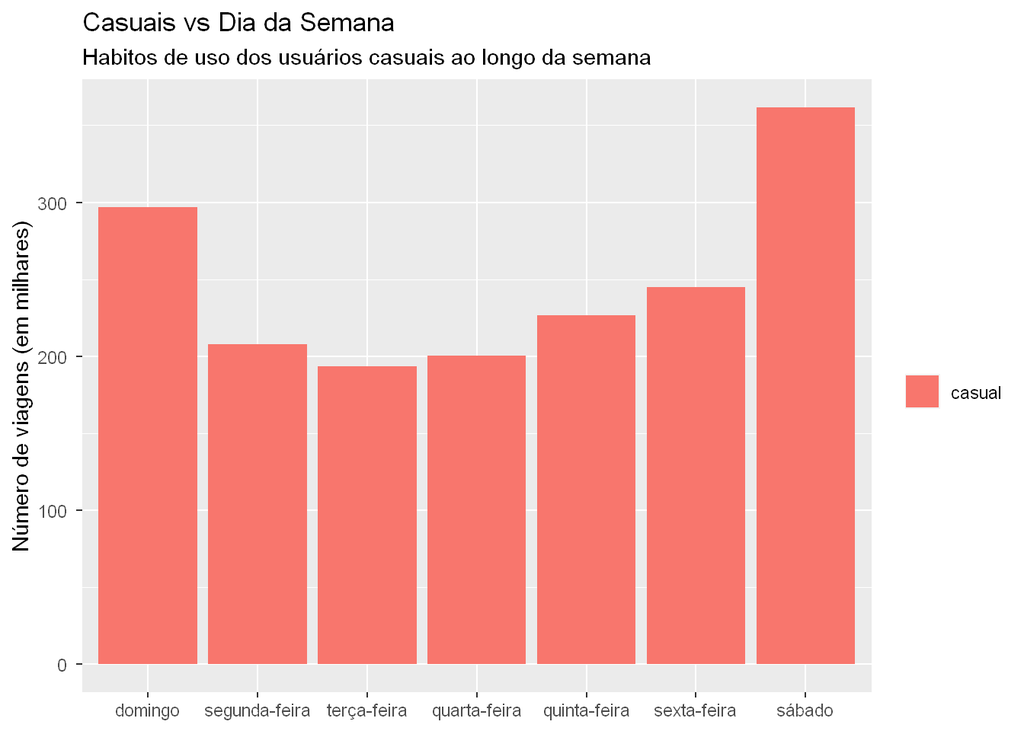

```r
    ggplot(data = cyclistic_viagens_casual) +
        geom_bar(mapping = aes(x = weekday, fill=member_casual)) +
        scale_x_discrete (limits = ordem) +
        scale_y_continuous(labels= unit_format(unit="", scale=1/1e03, digits = 2)) +
        scale_fill_manual(values = "#F8766D") +
        labs(title="Casuais vs Dia da Semana",
             subtitle="Habitos de uso dos usuários casuais ao longo da semana" ,
             x=NULL,
             y="Número de viagens (em milhares)",
             fill="Tipo de usuário") +
        theme(legend.title = element_blank())
```

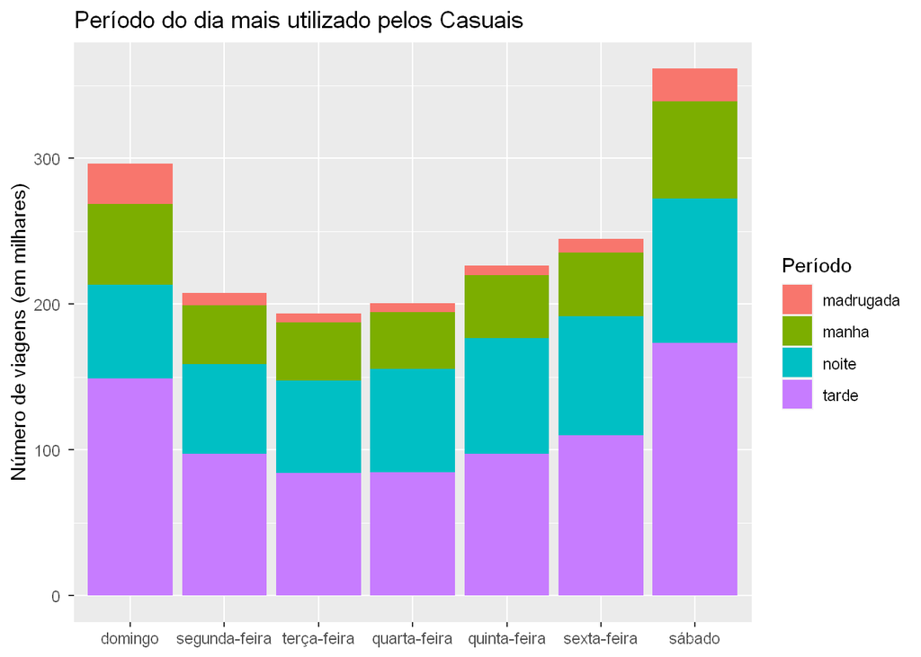

```r
    top_station_casual <- cyclistic_viagens_casual %>% count(start_station_name) %>% arrange(desc(n)) %>% head(10)
    worst_station_casual <- cyclistic_viagens_casual %>% count(start_station_name) %>% arrange(n) %>% head(10)
    bike_pref_casual <- cyclistic_viagens_casual %>% count(rideable_type) %>% arrange(n)
    weekdays_casual <- cyclistic_viagens_casual %>% count(weekday) %>% arrange(n)
    period_casual <- cyclistic_viagens_casual %>% count(periodo) %>% arrange(n)

    ggplot(data = cyclistic_viagens_casual) +
      geom_bar(mapping = aes(x = weekday, fill=periodo)) +
      scale_x_discrete (limits = ordem) +
      scale_y_continuous(labels= unit_format(unit="", scale=1/1e03, digits = 2)) +

      labs(title="Período do dia mais utilizado pelos Casuais",
             x=NULL,
             y="Número de viagens (em milhares)",
             fill="Período")
```

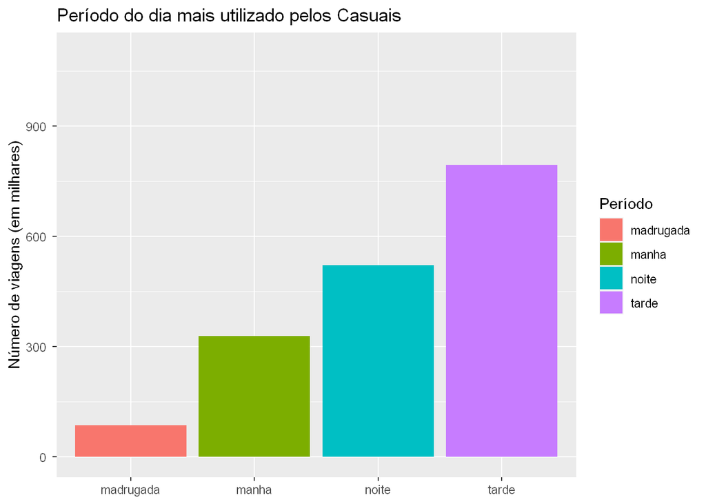

```r
    ggplot(data = cyclistic_viagens_casual) +
      geom_bar(mapping = aes(x = periodo, fill=periodo)) +
      #scale_x_discrete (limits = ordem) +
      scale_y_continuous(labels= unit_format(unit="", scale=1/1e03, digits = 2), limits = ajuste_y, breaks = quebras) +
      labs(title="Período do dia mais utilizado pelos Casuais",
             x=NULL,
             y="Número de viagens (em milhares)",
             fill="Período")
```

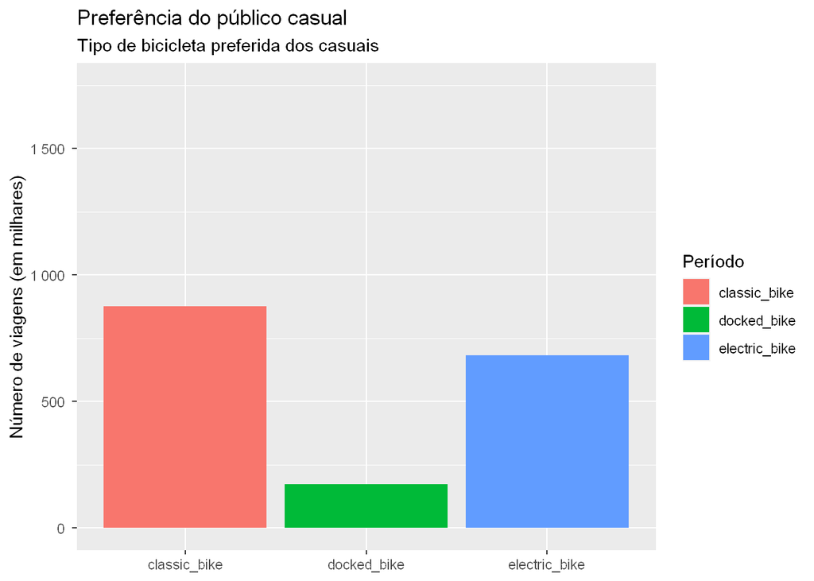

```r
    ggplot(data = cyclistic_viagens_casual) +
      geom_bar(mapping = aes(x = rideable_type, fill=rideable_type)) +
      #scale_x_discrete (limits = ordem) +
      scale_y_continuous(labels= unit_format(unit="", scale=1/1e03, digits = 2), limits = ajuste_y2) +
      labs(title="Preferência do público casual",
             subtitle = "Tipo de bicicleta preferida dos casuais",
             x=NULL,
             y="Número de viagens (em milhares)",
             fill="Período")
```

### Descobertas

Primeiro vale notar que há 74.464 registros onde a duração da viagem é inferior a 1 minuto e a bike foi pega e devolvida no mesmo ponto, ou seja, é possível que esses usuários tenham tido algum problema ou mesmo tenham desistido de utilizar as bikes, é necessário uma pesquisa a respeito desses usuários para descobrir os motivos de tanta desistência.

Para a nossa análise, esses registros serão deixados de lado por podem influenciar nas estatisticas básicas.

Há uma tendência clara dos membros em utilizar as bicicletas como meio de transporte para trabalho/escola pelo cruzamento dos dias da semana onde são mais utilizadas juntamente com o horário de uso.

O marketing deve trabalhar de modo a convencer os usuários casuais de que vale a pena utilizar as bikes para evitar trânsito, por serem menos poluentes e, principalmente, porque a media de tempo de cada corrida desses usuários é de 24 minutos - ao se tornar membro para bicicletas tradicionais você não paga pra retirar a bike e nem nenhum valor até 45 minutos de corrida (INFORMAÇÃO RETIRADA DO SITE QUE REALIZA O ALUGUEL DAS BICILETAS) - sendo muito vantajoso o plano.

Obs.: no futuro podemos criar um dataframe para colocar todas as médias em um único dataframe e plotar gráficos pelo próprio R, acabei fazendo esses gráficos mais simples no Excell